# P8105_hw2_jl5172

```r
library(tidyverse)  #load library
nyctransit = read.csv("./data/NYC_Transit_Subway_Entrance_And_Exit_Data.csv")
nyctransit = janitor::clean_names(nyctransit)  #clean names
```

Q1 Read and clean the data; retain line, station, name, station latitude / longitude, routes served, entry, vending, entrance type, and ADA compliance. Convert the entry variable from character (YES vs NO) to a logical variable (the ifelse or recode function may be useful).

```r
nycsubset1<-select(nyctransit,line,station_name,station_latitude,station_longitude,route1,route2,route3,route4,route5,route6,route7,route8,route9,route10,route11,entry,vending,entrance_type,ada)

# create nycsubset1 which contain required varibles using selection
```

Write a short paragraph about this dataset – explain briefly what variables the dataset contains, describe your data cleaning steps so far, and give the dimension (rows x columns) of the resulting dataset. Are these data tidy? #the dimension of cleaned dataset is 1868rows*19columns.There are 19 variables contained in this data: line,station_name,station_latitude, route1:route11,entry,vending,entrance_type and ada.The three reuqirements for tidy data are 1.Columns are variables. 2.Rows are observations 3.Every value has a cell.This dataset-nycsubset1 is not cosidered because not every value has a cell.

```r
nycdistinct<-distinct(nycsubset1,nycsubset1$station_name,nycsubset1$line,.keep_all = TRUE) # Use distinct function:distinct by station_name and line  to create a new dataframe named 'nycdistinct'
nrow(nycdistinct)  # Use nrow function to count number of rows for nycdistinct and thus number of distinct stations
```

```
## [1] 465
```

How many distinct stations are there? #There are 465 distinct stations here.

```r
sum(nycdistinct$ada) #use sum function to count ada==TRUE since TRUE==1 in R
```

```
## [1] 84
```

How many stations are ADA compliant? #84 stations are ADA compliant

```r
entrancenoven<-filter(nycdistinct,entry==TRUE & vending=="NO") # Use filter to select stations which statisfy conditions that have no vending but allow entrance

entrynovenproportion<-nrow(entrancenoven)/nrow(nycdistinct)  #Get proportion of entance w/o vending stations
```

What proportion of station entrances / exits without vending allow entrance? #0.0107527 of stations without vending allow entrance.

Reformat data so that route number and route name are distinct variables.

```r
gatherbindnyc<-gather(nycsubset1, key = routes, value=train,route1:route11,na.rm = TRUE)  # Use gather function gather values from columns route1:route11 into cells and thus we would have 13198 entries each represent one route & one train.
# In this way, each distinct stations would have several entries.
```

```r
serveA<-filter(gatherbindnyc,train=="A")
serveA<-distinct(serveA,serveA$station_name,serveA$line)
#filter to create dataframe that composed of entries serve A train and then distinct by station_name and line to find distinct stations that serve A train.
nrow(serveA)  # Use nrow to count number of distinct stations that serve A train.
```

```
## [1] 60
```

How many distinct stations serve the A train? #60 stations serve A train

```r
ADA<-filter(gatherbindnyc,ada=="TRUE"&train=="A")
ADA<-distinct(ADA,ADA$station_name,ADA$line)
# filter to create dataframe that composed of entries that is ADA compliant which serve A train at the same time
nrow(ADA)  # Use nrow to count the distinct stations that are ADA compliant & serving A train.
```

```
## [1] 17
```

Of the stations that serve the A train, how many are ADA compliant? #17 stations are ADA compliant.

# Question 2 Starts Here

Read and clean the Mr. Trash Wheel sheet: specify the sheet in the Excel file and to omit columns containing notes (using the range argument and cell_cols() function) use reasonable variable names omit rows that do not include dumpster-specific data rounds the number of sports balls to the nearest integer and converts the result to an integer variable (using as.integer)

```r
library(readxl) #load library
water<-read_excel("./data/HealthyHarborWaterWheelTotals2018-7-28.xlsx",sheet = 1,range = "A2:N338") #read excel first sheet from the dataset with range including cell A2 to cell N338 and thus removes the column with notes.
water<-filter(water,!is.na(water$Dumpster))  #use filter function to wipe out entries without value in Dumpster columns.
water$`Sports Balls`<-as.integer(round(water$`Sports Balls`)) #round the values in 'Sports Balls' and transform this column into integers
```

Read and clean precipitation data for 2016 and 2017. For each, omit rows without precipitation data and add a variable year. Next, combine datasets and convert month to a character variable (the variable month.name is built into R and should be useful). janitor clean name

```r
ppt_2017<-read_xlsx("./data/HealthyHarborWaterWheelTotals2018-7-28.xlsx", sheet = 4,range = "A2:B15") #read the 4th sheet from xlsx document which is the precipitation dataset for 2017
ppt_2016<-read_xlsx("./data/HealthyHarborWaterWheelTotals2018-7-28.xlsx", sheet = 5,range = "A2:B15") #read the 5th sheet from xlsx document which is the precipitation dataset for 2016
ppt_2017<-janitor::clean_names(ppt_2017) #clean names
ppt_2016<-janitor::clean_names(ppt_2016)
```

```r
ppt_2017<-filter(ppt_2017,!is.na(ppt_2017$total)&!is.na(ppt_2017$month))
ppt_2017<-mutate(ppt_2017,year=2017) #omit rows without value and add a variable year by mutate

ppt_2016<-filter(ppt_2016,!is.na(ppt_2016$total)&!is.na(ppt_2016$month))
ppt_2016<-mutate(ppt_2016,year=2016)  #omit rows without ppt data and add a varible year by mutate

ppt_1617<-rbind(ppt_2016,ppt_2017)  # combine two dataset
ppt_1617<-mutate(ppt_1617,month=month.name[month]) # convert month into character variable
```

Write a paragraph about these data: Based on my observations,‘Date’and ’Month’ are considered the most important variables in the datasets. The amount of precipitation changed as the date goes by and we can see a pattern that precipitation amount is relatively high during summer time and low during winter time due to the rainfall fluctuation.

```r
sum(ppt_2017$total)
```

```
## [1] 32.93
```

For available data, what was the total precipitation in 2017? #The total precipitation in 2017 is32.93.

```r
water_2016<-filter(water,Year=="2016")
median_2016<-median(water_2016$`Sports Balls`)
```

What was the median number of sports balls in a dumpster in 2016? #The median of sports balls in dumpster 2016 is 26

# Question 3 starts here

```r
devtools::install_github("p8105/p8105.datasets")
library(p8105.datasets) #install package and load package
data("brfss_smart2010")
```

For this question:

format the data to use appropriate variable names; focus on the “Overall Health” topic; exclude variables for class, topic,question,sample size, and everything from lower confidence limit to GeoLocation

```r
brfss<-janitor::clean_names(brfss_smart2010) #Clean names
brfss<-filter(brfss,topic == "Overall Health") #Use filter to focus on topic "Overall Health"
brfss<-select(brfss,year,locationabbr,locationdesc,response,data_value)
#keep columns we want by using select function
```

structure data so that values for Response (“Excellent” to “Poor”) are column names / variables which indicate the proportion of subjects with each response (which are values of Data_value in the original dataset) create a new variable showing the proportion of responses that were “Excellent” or “Very Good”

```r
brfss<-spread(brfss,key=response,value = data_value) #Use spread function spread Response across multiple columns
brfss<-mutate(brfss,Excellentgood_proportion=(Excellent+`Very good`)/100)
#create a new column named
```

```r
uniquelocations<-nrow(distinct(brfss,locationdesc)) # use distinct function count number of distinct location,disrtinct by column locationdesc
```

How many unique locations are included in the dataset? #There are 404 distinct locations in the dataset.

```r
uniquestates<-nrow(distinct(brfss,locationabbr))
```

Is every state represented?  
#There are 51 states which have been represented.

```r
statemost<-brfss %>%
  group_by(locationabbr) %>%
  summarise(number=n()) #using group by to combine observations based on locationabbr and thus we can observe how many times a state has been observed.
statemost<-filter(statemost,statemost$number== max(statemost$number)) #use filter to find out the state with maximum number in column:number
statemost<-statemost$locationabbr # thus finding the most observed state
```

What state is observed the most? #NJhas been observed the most.

```r
brfss_2002<-filter(brfss,year==2002)  # Use filter to create new dataframe that cover data in 2002 only.
median_2002<-median(brfss_2002$Excellent,na.rm=TRUE) # Calulate the median of excellent reponse in 2002 by using built-in function
```

In 2002, what is the median of the “Excellent” response value? #In 2002, 23.6 is the median of “Excellent” response value

Make a histogram of “Excellent” response values in the year 2002.

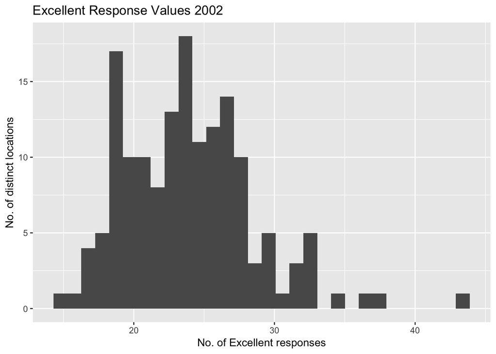

```r
brfss_2002 %>%  # Plotting using the data from brfss_2002 that contain 2002 data only.
  ggplot(aes(x = Excellent))+  #Using ggplot to plot histogram
  geom_histogram()+
  labs(x="No. of Excellent responses", y= "No. of distinct locations",title="Excellent Response Values 2002")
```

```r
# x-axis is the proportion of excellent
# y-axis is the number of locations.
```

Make a scatterplot showing the proportion of “Excellent” response values in New York County and Queens County (both in NY State) in each year from 2002 to 2010.

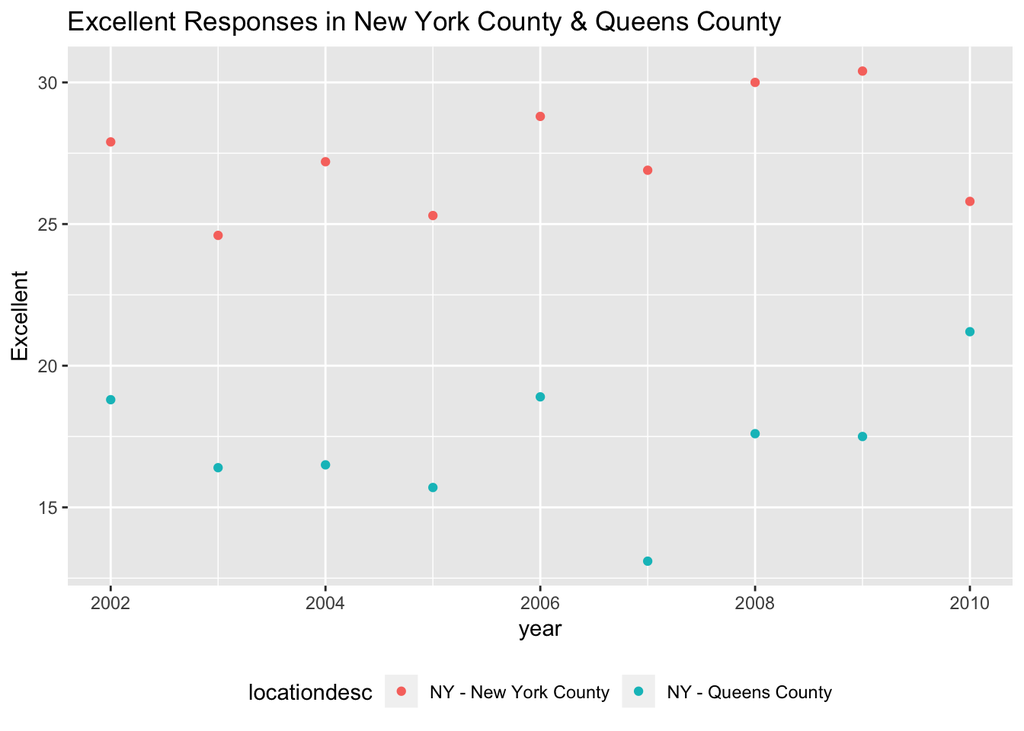

```r
NYC_QC_2002_2010<-filter(brfss,locationdesc=="NY - New York County"|locationdesc=="NY - Queens County")

NYC_QC_2002_2010 %>%
  ggplot(aes(x = year, y= Excellent ,color =locationdesc))+
           geom_point()+
           labs(x="year", y= "Excellent",title="Excellent Responses in New York County & Queens County" )+
  theme(legend.position = "bottom")
```